# General Linear Model (3)

## Confounding

General interpretation of model coefficients:  
Effect of the corresponding \(x\) on \(y\), **given all other predictors**

- Coefficients will generally change if we change the model  
  (i.e., eliminate, or add, predictors)
- This provides a way to assess **confounding**:
  - Model 1: \(\quad y = \beta_0 + \beta_1 x_1 + \epsilon\)
  - Model 2: \(\quad y = \beta_0 + \beta_1 x_1 + \beta_2 x_2 + \epsilon\)

\(x_2\) is a **counfounder** for \(x_1\), if the effect of \(x_1\) (that is, \(\beta_1\))  
is different in Model 1 and Model 2

## Confounding example (simulated data)

- Suppose an observational study comparing lipid lowering drugs A and B
- Colesterol is measured pre- and pos-treament

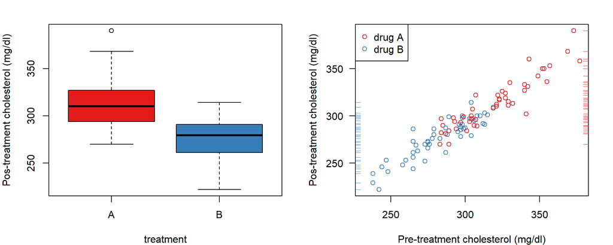

## Modelling pos-treatment values (y)

- A first model (m1) including only **treatment** as predictor (A is the reference level)
- A second model (m2) including both **treatment** and **pre-treatment values (x)**
- In both models, \(\beta_{treatmentB}\) is the expected **difference** betwen B and A (the **reference** level)

```r
m1 <-  lm(y ~ treatment); print(summary(m1)$coeff,digits=2)
```

```
            Estimate Std. Error t value Pr(>|t|)
(Intercept)      313        3.5    90.6  1.5e-95
treatmentB       -37        4.9    -7.6  1.7e-11
```

```r
m2 <-  lm(y ~ x + treatment); print(summary(m2)$coeff,digits=2)
```

```
            Estimate Std. Error t value Pr(>|t|)
(Intercept)    16.58     13.589     1.2  2.3e-01
x               0.93      0.042    21.9  3.6e-39
treatmentB     -3.10      2.523    -1.2  2.2e-01
```

- Note that treatment effect is no longer significant
- Note how small is now the estimated treatment effect

## The two models, grapically

In both plots, the treatment effect is the *vertical* distance between lines (A-B):

\(\qquad \qquad\) **m1**: quite obviously, -37 mg/dl \(\qquad \qquad \qquad\) **m2**: *given* \(x\), -3 mg/dl

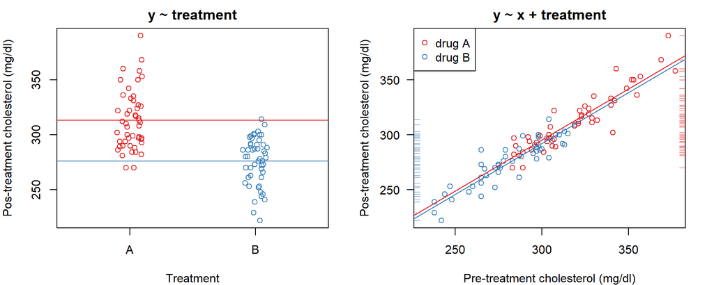

## Interaction

Interaction between two predictors \(x_1\) and \(x_2\):

- the effect of \(x_1\) is not constant, but depends on \(x_2\)
- the effect of \(x_2\) is not constant, but depends on \(x_1\)

If this is the case, we say that

- \(x_2\) is an effect modifier for \(x_1\)
- \(x_1\) is an effect modifier for \(x_2\)

## Interaction example

- Clinical trial on a lipid lowering drug vs placebo; blood colesterol is measured pre- and pos-treatment
- Note in this case pre-treatment values are similar in both treatment groups

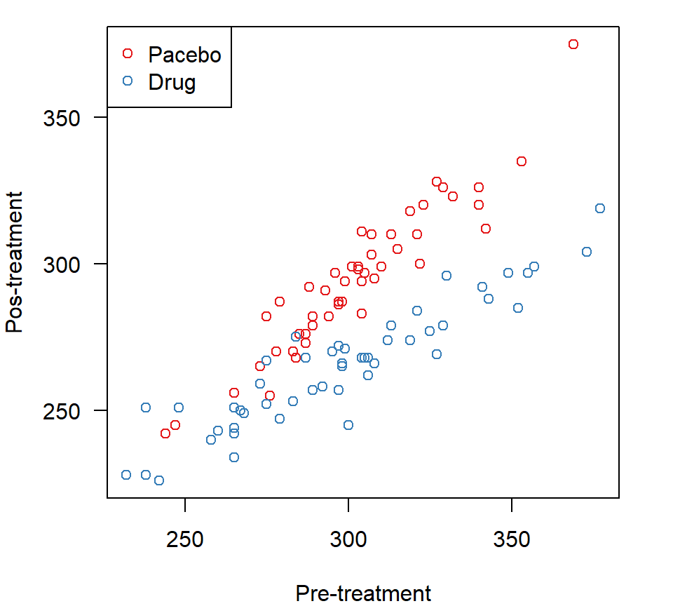

## Fitting models with/without interaction

```r
m1 <-  lm(y ~ x + t); print(summary(m1)$coeff, digits=2)          # without interaction
```

```
            Estimate Std. Error t value Pr(>|t|)
(Intercept)    92.13      9.896     9.3  4.1e-15
x               0.67      0.032    20.7  2.4e-37
t             -26.38      1.971   -13.4  9.1e-24
```

```r
m2 <-  lm(y ~ x + t + x:t); print(summary(m2)$coeff, digits=2)    # with interaction
```

```
            Estimate Std. Error t value Pr(>|t|)
(Intercept)     9.24     14.056    0.66  5.1e-01
x               0.94      0.046   20.39  1.2e-36
t              95.16     16.996    5.60  2.0e-07
x:t            -0.40      0.056   -7.18  1.5e-10
```

## The two models, grapically

In both cases we fit two lines (one for each treatment), but:

\(\qquad\) different intercept, same slope \(\qquad\) different intercept, different slope

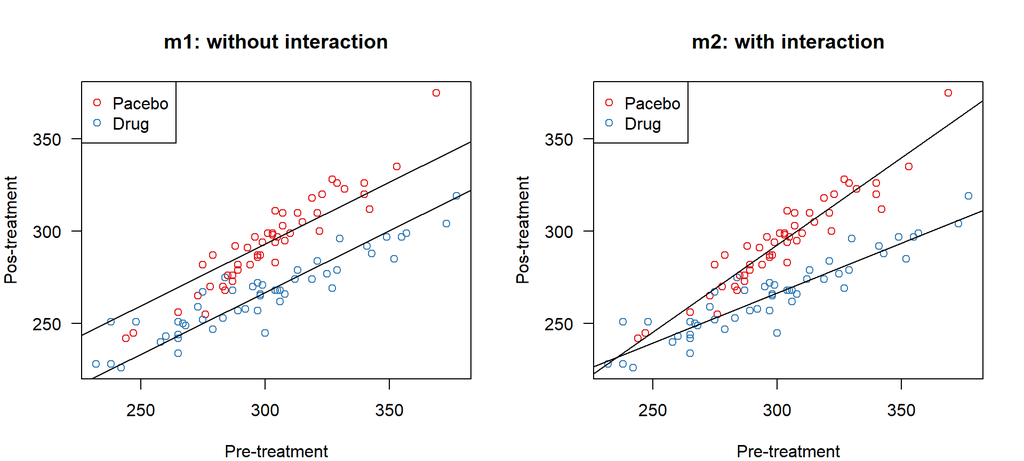

## Exercise 1

Use this code to read and prepare the `GLMsData::lungcap` dataset on lung capacity and smoking in 654 youth (see `?GLMsData::lungcap`).

```r
library(tidyverse)
library(GLMsData)
data(lungcap)                                            # get the dataset

d <- lungcap %>%
  janitor::clean_names() %>%
  mutate(height = round(2.54 * ht),                       # converts from inches to cm
         gender = as.factor(gender),                      # creates factor for gender
         smoke = factor(smoke,                            # creates factor for smoke
                        levels = 0:1,
                        labels = c("no", "yes"))) %>%
  select(-ht)                                             # drops ht
```

## Exercise 1 (cont)

1. Describe variables in dataframe `d`.
2. Produce boxplots of:
   - `fev` by `smoke`, and
   - `age` by `smoke`.
3. Fit a model for `fev` with `smoke` as predictor; what is the effect of `smoke` on `fev`?
4. Fit a second model by adding `age` as predictor; what is now the effect of `smoke` on `fev`?
5. Do you think `age` is a confounder for `smoke`?

## Exercise 2 (Recap)

1. Subset non-smokers into a new dataframe to conduct the following analysis.
2. Fit a model for `fev` with `height` and `gender` as predictors:
   - get a summary of the model and interpret the model coefficients.
   - plot the data along with the model.
   - assess model assumptions graphically; is there any non-linearity?
   - does a polynomial for `height` improve the fit?
   - re-assess model assumptions; is there any remaining problem?
   - fit a model with `log(fev)` as the dependent variable.
   - reassess model assumptions.
   - plot the data and overlay the model.